# Análisis de Precipitación y Temperatura

Marina Pachón Mena

2025-02-24

## Introducción

En este documento reproducible, se presenta un análisis detallado de los **datos climáticos** de diversas especies del género *Pinus* y sus respectivas localizaciones. El conjunto de datos que se utiliza proviene de una serie de archivos los cuales contienen información sobre las precipitaciones y las temperaturas medias anuales de diferentes especies en distintas elevaciones.

Las **especies** en las que se ha centrado nuestro análisis son las siguientes:

- *Pinus halepensis*
- *Pinus nigra*
- *Pinus pinaster*
- *Pinus sylvestris*

Este análisis forma parte de un proyecto más amplio cuyo propósito es estudiar cómo las variables climáticas influyen en las especies vegetales y sus capacidades de adaptación a distintas condiciones ambientales.

## Objetivos

El objetivo principal de este análisis es calcular y visualizar los valores **promedios** y **desviaciones estándar** de la **precipitación** y **temperatura** anual por especie y por localización para responder a las actividades planteadas en los modulos de *Introducción a la programación*<sup>1</sup> y *Reproducibilidad*<sup>2</sup>.

## Metodología

Para el análisis se han empleado técnicas estadísticas vistas previamente en la asignatura [ecoinformática](https://ecoinfugr.github.io/ecoinformatica/) para obtener una visión general de cómo las especies y sus ubicaciones geográficas afectan las variables climáticas a lo largo del tiempo.

En la primera parte del análisis, se realizó una *transformación* de los datos utilizando funciones en R<sup>3</sup>, como `map()` para aplicar una operación a cada archivo y `bind_rows()` para combinar los resultados en un único **dataframe** homogéneo. Posteriormente, se calcularon las medias anuales de la temperatura y la precipitación, segmentadas por especie y localización.

Para la representación de las **precipitaciones promedio anuales** por especie y por ubicación, se han generado un *gráfico de barras* al cual se les ha incluído las **desviaciones estándar** previamente calculadas para ilustrar la variabilidad.

La siguiente parte del documento incluirá gráficos generados a partir de los datos procesados, como *gráficos de barras* que representan las **precipitaciones anuales promedio** por especie y por ubicación, junto con las **desviaciones estándar** para ilustrar la variabilidad.

## Resultados

Para lograr cada uno de nuestros objetivos se han abordado diferentes apartados:

### **1**- Creación de un bucle que lea los archivos climáticos y los guarde en una lista, pero añadiendo el nombre de cada sitio (obtenido del nombre del archivo).

A continuación, se presenta el código utilizado para leer los archivos climáticos de cada especie y localización, guardarlos en una lista y añadir el nombre del sitio a los datos.

```r
# Carga de paquetes necesarios
library(tidyverse)

# Definimos la ruta de la carpeta donde están los archivos
ruta_clima <- "data/clima/"

# Obtenemos la lista de archivos .csv que tenemos en nuestra carpeta clima
archivos_clima <- list.files(path = ruta_clima, pattern = "*.csv", full.names = TRUE)

# Queremos darle nombres a los distintos .csv y que aparezcan como nombres de la lista

nombres_sitios <- archivos_clima %>%
  basename() %>%
  str_remove("clima_") %>%
  str_remove(".csv")

# Función para leer los archivos
leer_archivo_clima <- function(archivo) {
  datos <- read_csv(archivo)  # Cargamos el archivo y lo guardamos en datos
  datos  # Devolvemos el dataframe
}

# Aplicamos la función a todos los archivos para guardarlos en una lista
lista_datos_clima <- map(archivos_clima, leer_archivo_clima)

# Asignamos los nombres a la lista
names(lista_datos_clima) <- nombres_sitios

# Verificamos los nombres de los elementos de la lista
names(lista_datos_clima)

# Verificamos que la lista tenga las listas cargadas correctamente
str(lista_datos_clima[[1]])
```

Como verificamos, nuestra lista tiene una estructura conforme a nuestros objetivos:

```r
# Verificamos que la lista tenga las listas cargadas correctamente
str(lista_datos_clima[[1]])
```

```
## spc_tbl_ [620 × 6] (S3: spec_tbl_df/tbl_df/tbl/data.frame)
##  $ sp_elev     : chr [1:620] "halepensis_high" "halepensis_high" "halepensis_high" "halepensis_high" ...
##  $ year        : num [1:620] 1971 1971 1971 1971 1971 ...
##  $ month       : num [1:620] 1 2 3 4 5 6 7 8 9 10 ...
##  $ monthly_pet : num [1:620] 12.5 17.4 14.7 28.6 43.7 ...
##  $ monthly_tmed: num [1:620] 5.1 6.59 5.01 7.83 9.89 ...
##  $ monthly_prec: num [1:620] 38.4 0.8 49.8 145.1 36.2 ...
##  - attr(*, "spec")=
##   .. cols(
##   ..   sp_elev = col_character(),
##   ..   year = col_double(),
##   ..   month = col_double(),
##   ..   monthly_pet = col_double(),
##   ..   monthly_tmed = col_double(),
##   ..   monthly_prec = col_double()
##   .. )
##  - attr(*, "problems")=<externalptr>
```

### **2**- Generación de un dataframe homogéneo a partir de la lista generada.

Sí, hemos podido generar un dataframe homogéneo a partir de la lista generada:

```r
# Carga de paquetes necesarios
library(tidyverse)

# Ejecutamos el script anterior para cargar la lista de datos
source("scripts/bucle_guardado.R")

# Unimos todos los dataframes de la lista en uno solo con esta función
df_clima <- bind_rows(lista_datos_clima)

# Separamos la columna sp_elev en dos nuevas columnas: sp y altitud:

# Podría hacer este paso usando filtros con la función case_when y str_detect
# pero la función separate me parece más limpia y rápida en este caso.

df_clima <- df_clima %>%
  separate(col = sp_elev, into = c("sp", "elevation"), sep = "_", remove = FALSE)

# Guardamos el dataframe final en un archivo .csv.
write_csv(df_clima, "data/df_clima.csv")
```

Para ello, utilizamos la función bind_rows(), que nos permite combinar los 12 dataframes individuales (uno por cada archivo de datos climáticos) en un **único dataframe** con **7.440** filas y **8** columnas.

El dataframe mantiene la siguiente estructura con las siguientes variables:

- *sp_elev*: Identifica la especie y el gradiente altitudinal de cada parcela.
- *sp*: Especie a la que pertenece la parcela (halepensis, nigra, pinaster, sylvestris).
- *elevation*: Gradiente altitudinal (low, medium, high).
- *year* y *month*: Indican el año y el mes de la observación.
- *monthly_pet*: Evapotranspiración mensual.
- *monthly_tmed*: Temperatura media mensual.
- *monthly_prec*: Precipitación mensual.

```r
head(df_clima)
```

```
## # A tibble: 6 × 8
##   sp_elev         sp         elevation  year month monthly_pet monthly_tmed monthly_prec
##   <chr>           <chr>      <chr>     <dbl> <dbl>       <dbl>        <dbl>        <dbl>
## 1 halepensis_high halepensis high       1971     1        12.5         5.10       38.4
## 2 halepensis_high halepensis high       1971     2        17.4         6.59        0.800
## 3 halepensis_high halepensis high       1971     3        14.7         5.01       49.8
## 4 halepensis_high halepensis high       1971     4        28.6         7.83      145.
## 5 halepensis_high halepensis high       1971     5        43.7         9.89       36.2
## 6 halepensis_high halepensis high       1971     6        80.5        15.6        10.2
```

**Ha sido posible crear esta dataframe porque todos los archivos compartían la misma estructura de columnas y tipos de datos.**

Finalmente, hemos añadido **dos nuevas columnas** (*sp* y *elevation*) separando la información contenida en *sp_elev*, para faciliar los análisis posteriores.

### **3**- Cálculo de los valores promedio de temperatura media anual por sitio; y por especie.

La temperatura media anual se calcula para tres niveles: por ubicación, por especie, y por especie y ubicación.

```r
# Carga de paquetes necesarios
library(tidyverse)

# Cargamos el dataframe generado anteriormente
df_clima <- read_csv("data/df_clima.csv")

# Calculamos la temperatura media anual por ubicación
temp_media_elev <- df_clima %>%
  group_by(elevation, year) %>%
  summarise(temp_media_anual = mean(monthly_tmed, na.rm = TRUE)) %>%
  ungroup()

# Calculamos la temperatura media anual por especie
temp_media_sp <- df_clima %>%
  group_by(sp, year) %>%
  summarise(temp_media_anual = mean(monthly_tmed, na.rm = TRUE)) %>%
  ungroup()

# Calculamos la temperatura emdia anual por especie y ubicación
temp_media_sp_elev <- df_clima %>%
  group_by(sp, elevation, year) %>%
  summarise(temp_media_anual = mean(monthly_tmed, na.rm = TRUE)) %>%
  ungroup()

# guardado de dataframes con los distintos análisis
write_csv(temp_media_elev, "data/temp_media_elev.csv")
write_csv(temp_media_sp, "data/temp_media_especie.csv")
write_csv(temp_media_sp_elev, "data/temp_media_sp_elev.csv")
```

En resumen, los resultados muestran:

- **Temperatura media por ubicación**: Calcula la media de la temperatura anual para cada localización y año. Útil para analizar cómo varía la temperatura entre diferentes ubicaciones.
- **Temperatura media por especie**: Calcula la temperatura media anual para cada especie en todos las ubicaciones, lo cual ayuda a entender cómo cada especie experimenta las condiciones climáticas.
- **Temperatura media por especie y ubicación**: Combina ambos niveles anteriores, analizando la temperatura para cada especie en cada ubicación. Con esto obtenemos un análisis más detallado, ya que algunas especies pueden adaptarse de manera diferente a las condiciones de cada ubicación.

### **4**- Cálcula de los valores promedio (y la desviación estándar) de la precitación acumulada anual por sitio; y por especie. Y, representación con un gráfico de barras con los promedios de la precipitación y desviaciones estándar.

Para responder a esta pregunta hemos hecho un primer código centrándonos en calcular los valores promedio y la desviación estándar de la precitación anual acumulada por ubicación; y por especie.

```r
# Carga de paquetes necesarios
library(tidyverse)

# Cargamos el dataframe generado anteriormente
df_clima <- read_csv("data/df_clima.csv")

# Calculamos la precipitación anual total por especie y elevación
precip_anual <- df_clima %>%
  group_by(sp, elevation, year) %>%
  summarise(precip_total_anual = sum(monthly_prec, na.rm = TRUE)) %>%
  ungroup()

# Calculamos de la media y desviación estándar para cada especie
precip_media_sd_sp <- precip_anual %>%
  group_by(sp) %>%
  summarise(
    precip_media = mean(precip_total_anual, na.rm = TRUE),
    precip_sd = sd(precip_total_anual, na.rm = TRUE)
  )

# Calculamos de la media y desviación estándar para cada ubicación
precip_media_sd_elev <- precip_anual %>%
  group_by(elevation) %>%
  summarise(
    precip_media = mean(precip_total_anual, na.rm = TRUE),
    precip_sd = sd(precip_total_anual, na.rm = TRUE)
  )

# Calculamos la media y la desviación estándar de la precipitación anual a través de los años
precip_media_sd <- precip_anual %>%
  group_by(sp, elevation) %>%
  summarise(
    precip_media = mean(precip_total_anual, na.rm = TRUE),
    precip_sd = sd(precip_total_anual, na.rm = TRUE)
  ) %>%
  ungroup()

# guardado de dataframes con los distintos análisis
write_csv(precip_media_sd, "data/precip_media_sd.csv")
write_csv(precip_anual, "data/precip_anual.csv")
write_csv(precip_media_sd_sp, "data/precip_media_sd_sp.csv")
write_csv(precip_media_sd_elev, "data/precip_media_sd_elev.csv")
```

El motivo por el cual se realizan los cálculos para especies y ubicación es obtener una **visión completa** de cómo las condiciones climáticas (en este caso, la precipitación) afectan a las especies en distintas localizaciones y cómo se comportan en general. Esto también permite ver si ciertas especies se adaptan mejor a condiciones específicas de precipitación o si ocurre lo mismo en todas las ubicaciones.

Al final, para la **representación de los promedios de la precipitación** y sus **desviaciones estándar** usamos el dataframe generado anteriormente en el que se incluye la precipitación anual por especie y ubicación:

```r
# Carga de paquetes necesarios
library(tidyverse)
library(ggplot2)

# Cargamos los dataframe generados anteriormente
precip_media_sd <- read_csv("data/precip_media_sd.csv")

# Gráfico de barras con los promedios de la precipitación y las desviaciones estándar
precip_sp_elev_sd <- ggplot(precip_media_sd, aes(x = interaction(elevation), y = precip_media, fill = sp)) +
  geom_bar(stat = "identity", position = "dodge") +
  geom_errorbar(
    aes(ymin = precip_media - precip_sd, ymax = precip_media + precip_sd),
    width = 0.2,
    position = position_dodge(0.9)
  ) +
  labs(
    title = "Precipitación acumulada anual promedio por especie y localización",
    x = "Localización",
    y = "Precipitación acumulada anual promedio (mm)",
    fill = "Especies"
  ) +
  theme_bw() +
  theme(plot.title = element_text(hjust = 0.5))

# Guardamos los gráficos
ggsave("graphics/grafico_precip_sp_elev_sd.png", plot = precip_sp_elev_sd, width = 8, height = 6, dpi = 300)
```

Por lo tanto, obtenemos este **gráfico de barras**:

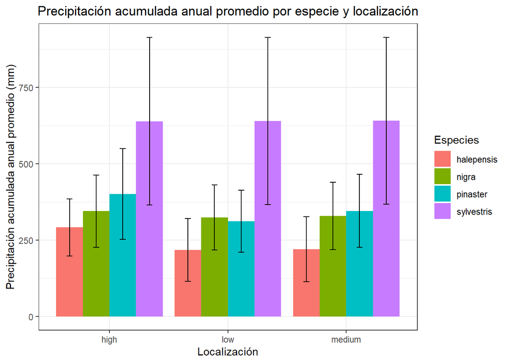

## Conclusiones

A lo largo de este trabajo, hemos logrado responder a todas las preguntas planteadas en los módulos de la asignatura de *Ecoinformática*. Aplicando herramientas de análisis de datos, estadísticas y visualización, hemos procesado y representado la información de la carpeta *clima*. Esto nos ha permitido extraer recursos para interpretar patrones ecológicos relevantes, consolidando así los conocimientos adquiridos en el curso.

[figure not shown]

## Extra: Visualizaión de Observaciones de *Tetrax tetrax* de iNaturalist

En esta sección, se ha realizado un análisis adicional utilizando datos obtenidos de la plataforma **GBIF**<sup>4</sup> sobre *Tetrax tetrax*. Tras descargar todas las observaciones disponibles, se ha filtrado el conjunto de datos para quedarnos únicamente con las observaciones de **iNaturalist**. Esta información incluye las coordenadas geográficas de cada observación, las cuales hemos utilizado para crear un mapa interactivo.

```r
# Cargamos los paquetes necesarios
library(tidyverse)
library(leaflet)
library(lubridate)

tetrax <- read_tsv("data/gbif/tetrax_gbif.csv")

# Filtramos solo las observaciones de iNaturalist que son las que nos vamos a quedar
tetrax_inat <- tetrax %>%
  filter(
    institutionCode == "iNaturalist",  # Filtra solo las observaciones de iNaturalist
    !is.na(decimalLatitude) & !is.na(decimalLongitude),  # Eliminamos NA (que los hay)
  )

# Convertimos esto a formato fecha
as_date(tetrax_inat$eventDate)

# Crear el mapa interactivo
mapa <- leaflet(tetrax_inat) %>%
  addTiles() %>%
  addCircleMarkers(
    lng = ~decimalLongitude,
    lat = ~decimalLatitude,
    radius = 4,
    color = "red",
    fill = TRUE,
    fillColor = "yellow",
    fillOpacity = 0.5,
    popup = ~paste("Fecha:", eventDate)
  )
```

[interactive chart not shown]

En el mapa, se han mostrado puntos correspondientes a cada observación de *Tetrax tetrax*, representados por círculos de color rojo. Además, al hacer clic sobre cualquier punto del mapa, aparece un *popup* que muestra la **fecha** de la observación registrada.

## Referencias

1.

Pérez-Luque, A. J. & Martínez-López, J. [Introducción a la Programación – Ciclo de Gestión de los Datos. Ecoinformática](https://ecoinfugr.github.io/ecoinformatica/modulos/programacion.html). *Ciclo de Gestión de los Datos. Ecoinformática* (2025).

2.

Pérez-Luque, A. J. [Práctica Documentos Reproducibles – Ciclo de Gestión de los Datos. Ecoinformática](https://ecoinfugr.github.io/ecoinformatica/practicas/pr_repro_documentos_reproducibles.html). *Ciclo de Gestión de los Datos. Ecoinformática* (2025).

3.

Crawley, M. J. *The R Book*. (John Wiley & Sons Inc, Hoboken, N.J, 2013).

4.

GBIF.Org User. Occurrence download. (2025) doi:10.15468/DL.YZ4K5W.